# 1차 보고서 — 피드백 반영 내용 (별도 정리)

기준: 관악구 · 도로 침수 = 도로수위계 ≥15cm(서울시) · 작성 2026-06-30 · 원본 보고서와 분리

아래는 1차 보고서에 받은 피드백 7건과 그 반영 내용만 모은 것입니다. (2차 발견 사항은 별도 문서로 분리)

### ① 침수 조건 설명 추가 (+ 출처)반영 완료

**피드백**: 진행 경과/실패 사유 — 침수 조건 설명 추가 (어떤 출처 기반인지 명시)

**침수 양성 = 도로수위계 침수심 ≥ 15cm** (임의 임계가 아니라 **서울시 침수 예보 발령 기준**).

- **출처**: 서울시 (news.seoul.go.kr/env/archives/522983) — *"①시간당 강우량 55mm 초과 ②15분당 강우량 20mm 초과 **③도로수위계 기준 침수심 15cm 초과** 중 어느 하나라도 해당되면 자치구 단위 '침수 예보' 발령."*
- 세 조건 중 **③ 도로수위계 수위 항(15cm)**을 침수 양성 정의로 채택. 강우 항은 별도 입력으로 사용.
- **하수 충전율(만관·위험수위)은 침수 기준이 아니라 별개 신호로 분리** (도로 표면 침수 ≠ 하수관 만관).

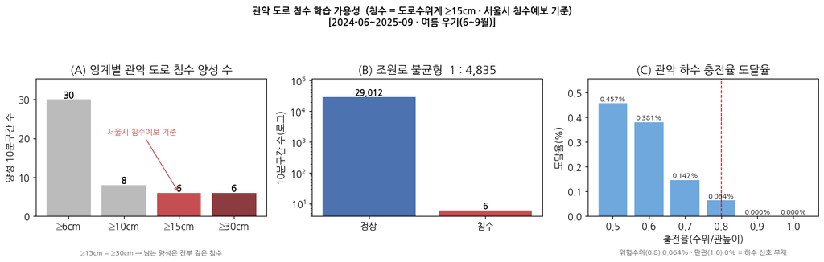

도로수위계 ≥15cm(서울시 기준) 적용 시 관악 도로 침수 양성 가용성. 모든 그림에 측정기간 표기(⑥).

### ② 도로 노면 오작동·미판정 근거 제시반영 완료

**피드백**: 도로 노면 오작동 및 미판정에 대하여 오작동에 대한 근거 제시 필요

- **봉천동 911-14**: 겨울 100%·고착 71%·고유값 3 = 겨울 사각파형 신호 → 오작동 근거 명확.
- ≥15cm(서울시 기준) 적용 시 오작동·저수위 센서는 0으로 탈락, 조원로 5-6만 잔존.

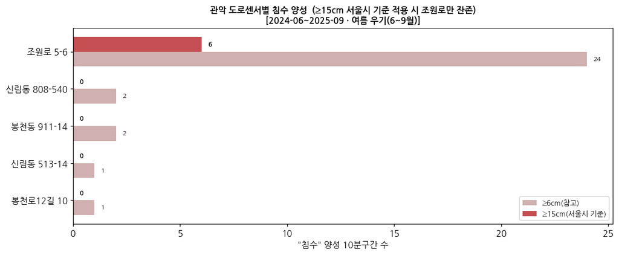

### ③ 강우-수위 동시반응(리드타임 0) — 조원로 기준 상세반영 완료

**피드백**: 강우-수위 동시 반응으로 리드타임 0인 부분을 조원로 기준으로 자세한 설명 필요

**조원로 5-6에서 강우-수위가 거의 동시 반응 → 리드타임 ≈ 0.**

- 조원로 일대 소유역은 작고(평균 ≈0.74km²)·불투수율이 높아 **도달시간(time of concentration)이 분 단위** → 비가 내리면 도로 수위가 거의 동시에 상승.
- 조원로의 강우계(점 강우)는 빗방울이 계기에 닿는 순간 이미 비가 온 것 → **수위를 앞설 수 없음(리드타임 0)**.
- 상류에서 다가오는 강우장을 먼저 보는 **격자 강우(레이더)**만이 조원로 수위를 시간적으로 앞서는 입력이 된다.

### ④ 해상도·강우장 데이터 요구조건 근거반영 완료

**피드백**: 해상도 및 강우장 데이터 요구 조건에 대한 근거 제시 필요

- **공간 ≤1km**: 관악 면적 ≈ 29.57km², 소유역 40개 → 평균 소유역 ≈ 0.74km². 1km 격자(1km²)는 소유역당 채 1셀이 안 돼 **분해 최소선이 1km**, 500m면 소유역당 ~3셀로 맨홀별 강우 차등 가능. (관악 전역 = 1km ~30셀 / 500m ~120셀)
- **시간 5~10분**: 도시 소유역(평균 0.74km²·불투수)의 도달시간이 분~십수 분 → 반응이 빨라 10분보다 성긴 자료는 첨두를 놓침.
- **상류 포함**: 리드타임 = 강우장의 상류→관악 이동시간. 이류속도 ~30~50km/h → 30분 리드타임엔 상류 **~15~25km** 강우장 필요.

### ⑤ DEM 필요성 근거 (SWMM 현 단계 배제)반영 완료

**피드백**: SWMM은 초기 모델 복잡도 때문에 현재는 배제. DEM이 노드-엣지 연결에 정말 필요한지 구체적 근거로 필요성 어필

**DEM은 노드-엣지(맨홀-관로) 연결용이 아니다** — 연결은 KICT GIS 관저고로 이미 확보·검증(차수 80%·공간정합 77%). DEM이 필요한 건 **노드 입력(맨홀별 유입)의 결손**을 채우기 위함:

- **① 집수면적**: 맨홀 유입 = 강우 × 집수면적(Q=C·i·A). 강우만으론 부피가 안 나오고 면적이 곱해져야 유입량. 공식 소유역 40개는 맨홀 12,184개 대비 너무 coarse → 맨홀별 정밀 집수면적은 **DEM 흐름누적·저지대 분석으로만** 도출.
- **② 표면류 경로**: 관악 침수=표면류형 → 관망 밖 지표에서 물이 모임. DEM 저지대·흐름방향이 "어느 맨홀로 물이 모이나" 제공.
- **③ 노드 변별력**: 집수면적 없으면 강우가 모든 맨홀에 균일 입력 → 노드 차이·상관신호 안 뜸.
- **SWMM은 현 단계 배제** (모델 복잡도).

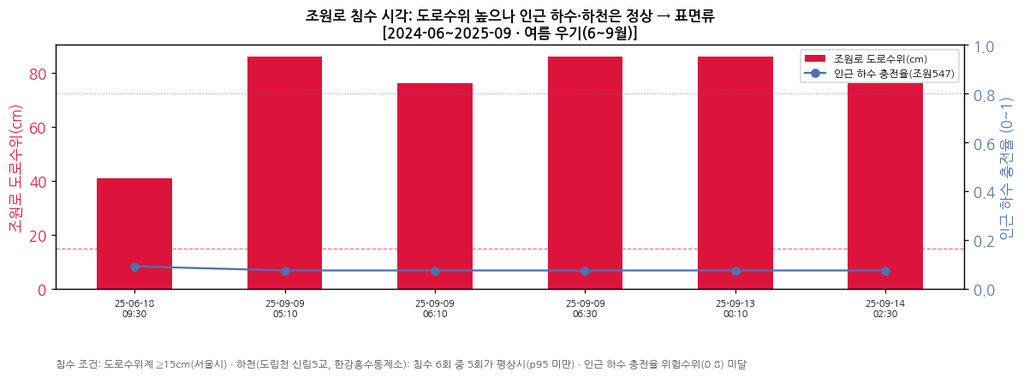

조원로 침수 시각: 도로수위는 높으나 인근 하수·하천은 정상 → 표면류 = DEM(지형) 필요 근거.

### ⑥ 각 시각화에 측정 년도·시기 표기반영 완료

**피드백**: 각 시각화 자료에 측정 년도와 시기 동시 표기

요청서용 그림 **6개 전부**에 측정기간을 제목/캡션에 표기 완료: **[2024-06~2025-09 · 여름 우기(6~9월)]**.

- req_why_infeasible · req1_label_contamination · req_river_useless · req2_dem_rationale · req_sewer_reach (+ req_leadtime).

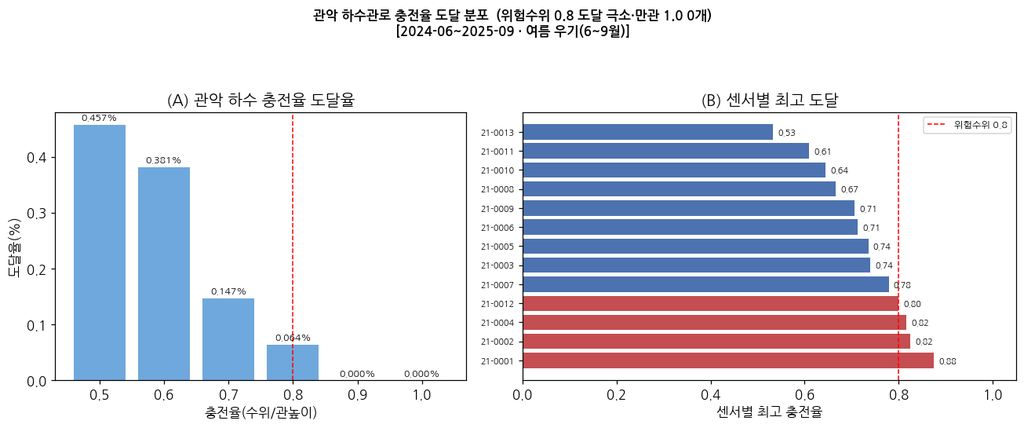

관악 하수 충전율 도달 분포 — 제목에 측정기간 표기(⑥ 적용 예시).

### ⑦ 그림6(하천) 보충 + 하천 출처 표기반영 완료

**피드백**: 그림 6도 침수 조건 설명에 따른 보충 설명을 하단 문구에 표기, 하천 데이터 출처도 표기

하천(하천역류 기각) 그림 하단에 **침수 조건(도로수위계 ≥15cm·서울시)**과 **하천 데이터 출처**를 명기.

- **하천 출처**: 한강홍수통제소(HRFCO) 도림천 신림5교, 2024-06~2025-09.
- 침수 시각의 도림천 수위가 대부분 평상시(p95 미만)임을 표기 → 하천역류가 침수 원인이 아님(표면류).

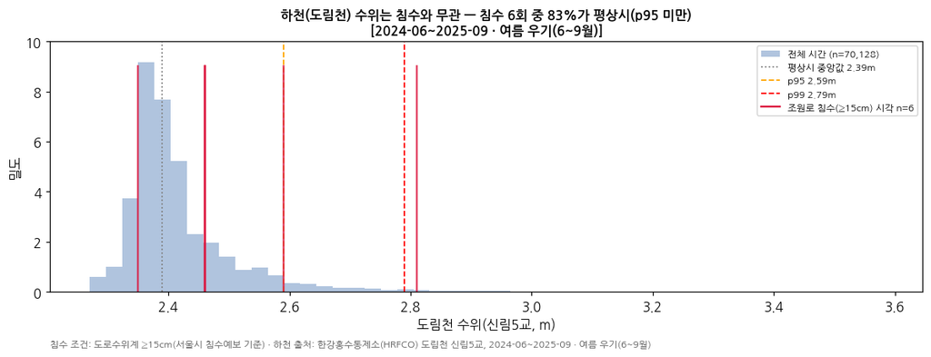

하천(도림천) 수위 — 하단에 침수 조건 + 하천 출처(한강홍수통제소 신림5교) 표기.